# Exam: Base de données MALARIA 2018-11-13

05/11/2020

# 1 Introduction

La base de données sur laquelle porte l’étude regroupe l’ensemble des décès dus au paludisme, entre 1990 et 2016, par tranche d’âge dans le monde au fil des années. L’objectif est de faire une description de la base de données en la soumettant à des questions. Une visualisation des données sera faite selon le résultat attendu. Il faudra prendre en compte la présence de l’indice de développement social(faible, moyen, élevé).

# 2 Chargement librairie

```r
library(tidyverse)
library(dplyr)
```

# 3 Importation des données

```r
malaria_deaths_age <-read_csv("https://raw.githubusercontent.com/rfordatascience/tidytuesday/master/data/2018/2018-11-13/malaria_deaths_age.csv")
```

# 4 Vérification importation et structure des données

```r
#------importation

malaria_deaths_age
```

```
## # A tibble: 30,780 x 6
##       X1 entity      code   year age_group deaths
##    <dbl> <chr>       <chr> <dbl> <chr>      <dbl>
##  1     1 Afghanistan AFG    1990 Under 5     185.
##  2     2 Afghanistan AFG    1991 Under 5     192.
##  3     3 Afghanistan AFG    1992 Under 5     197.
##  4     4 Afghanistan AFG    1993 Under 5     207.
##  5     5 Afghanistan AFG    1994 Under 5     226.
##  6     6 Afghanistan AFG    1995 Under 5     236.
##  7     7 Afghanistan AFG    1996 Under 5     251.
##  8     8 Afghanistan AFG    1997 Under 5     258.
##  9     9 Afghanistan AFG    1998 Under 5     273.
## 10    10 Afghanistan AFG    1999 Under 5     272.
## # … with 30,770 more rows
```

```r
#------Controle de la structure
str(malaria_deaths_age)
```

```
## Classes 'spec_tbl_df', 'tbl_df', 'tbl' and 'data.frame': 30780 obs. of  6 variables:
##  $ X1       : num  1 2 3 4 5 6 7 8 9 10 ...
##  $ entity   : chr  "Afghanistan" "Afghanistan" "Afghanistan" "Afghanistan" ...
##  $ code     : chr  "AFG" "AFG" "AFG" "AFG" ...
##  $ year     : num  1990 1991 1992 1993 1994 ...
##  $ age_group: chr  "Under 5" "Under 5" "Under 5" "Under 5" ...
##  $ deaths   : num  185 192 197 207 226 ...
##  - attr(*, "spec")=
##   .. cols(
##   ..   X1 = col_double(),
##   ..   entity = col_character(),
##   ..   code = col_character(),
##   ..   year = col_double(),
##   ..   age_group = col_character(),
##   ..   deaths = col_double()
##   .. )
```

# 5 Manipulation du jeu de données

Le tableau de données a 6 colonnes. On va les renommer afin de mieux se familiariser avec la base de données. Etant donné que les colonnes “X1” et “code” n’ont pas d’importance, il est préférable de les supprimer.

```r
malaria_deaths_age %>%
  rename(pays = entity, annee = year, tranche_age = age_group, nbr.deces=deaths) %>%
  select( -X1, -code)-> data
data
```

```
## # A tibble: 30,780 x 4
##    pays        annee tranche_age nbr.deces
##    <chr>       <dbl> <chr>           <dbl>
##  1 Afghanistan  1990 Under 5          185.
##  2 Afghanistan  1991 Under 5          192.
##  3 Afghanistan  1992 Under 5          197.
##  4 Afghanistan  1993 Under 5          207.
##  5 Afghanistan  1994 Under 5          226.
##  6 Afghanistan  1995 Under 5          236.
##  7 Afghanistan  1996 Under 5          251.
##  8 Afghanistan  1997 Under 5          258.
##  9 Afghanistan  1998 Under 5          273.
## 10 Afghanistan  1999 Under 5          272.
## # … with 30,770 more rows
```

*1.Nombre de deces dus au paludisme en 1990 en Afghanistan par tranche d’age?*

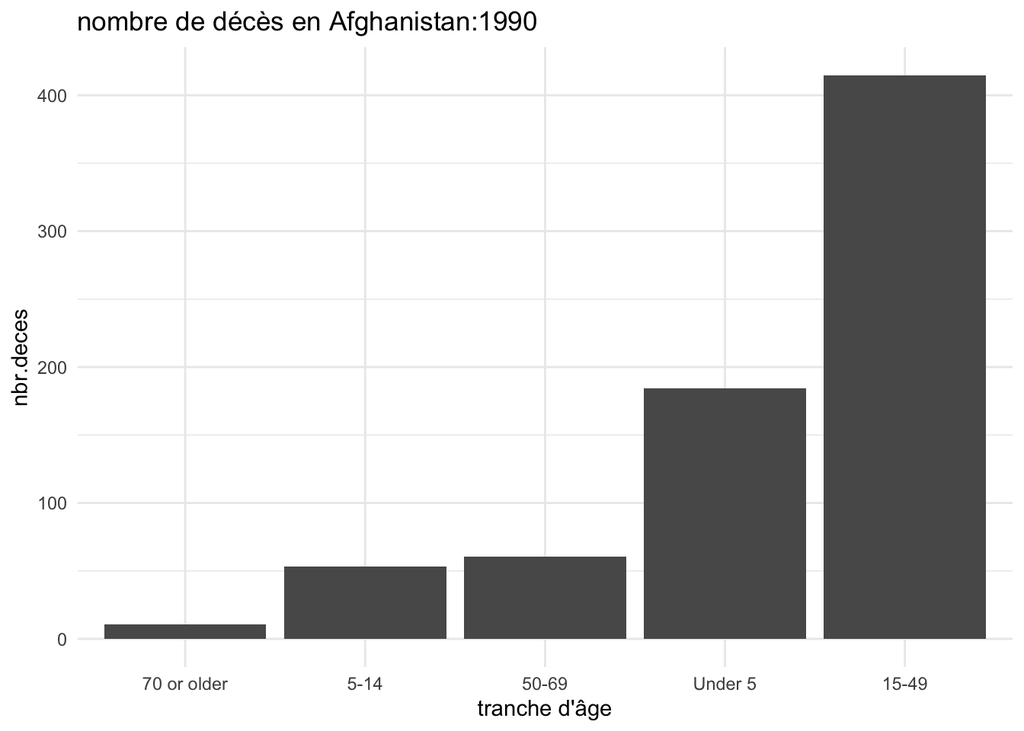

```r
data %>%
  filter(annee == 1990 & pays == "Afghanistan") %>%
  ggplot(aes(x=reorder(tranche_age,nbr.deces), y = nbr.deces), fill)+
  geom_col()+
  labs(title = "nombre de décès en Afghanistan:1990")+
  xlab("tranche d'âge")+
  theme_minimal()
```

*2.Quelle est l’evolution du nombre de décès dus au paludisme* *au Sénégal de 1990 à 2016?*

> Etapes
- Trier le jeu de données: décès dus au paludisme au Sénégal(filter)
- Faire un group_by année
- Faire un sumarise pour le nombre de décès par an
- Faire une représentation graphique

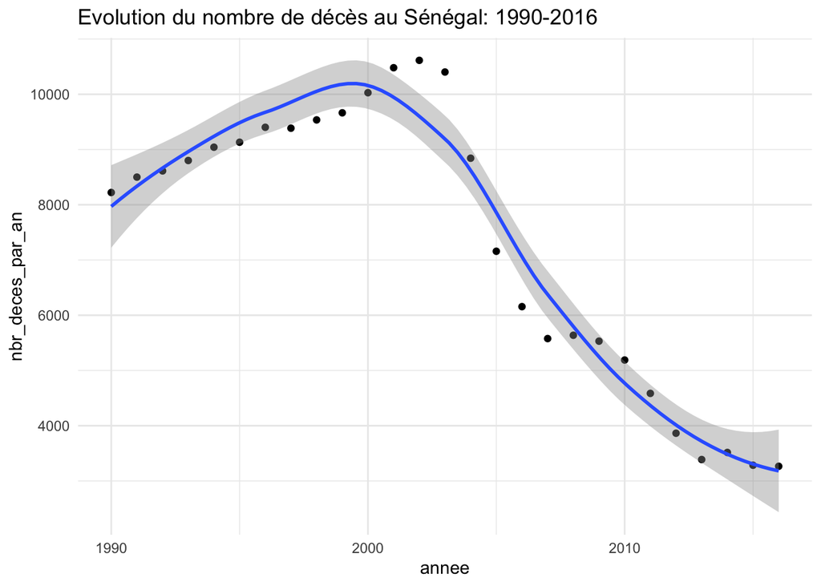

```r
data %>%
  filter(pays == "Senegal") %>%
  group_by(annee) %>%
  summarise(nbr_deces_par_an = sum(nbr.deces)) %>%
  ggplot(aes(x = annee, y = nbr_deces_par_an))+
  geom_point()+
  geom_smooth()+
  theme_minimal()+
  labs(title = "Evolution du nombre de décès au Sénégal: 1990-2016")
```

*3.Quelle est l’evolution du nombre de décès dus au paludisme* *en Argentine de 1990 à 2016?*

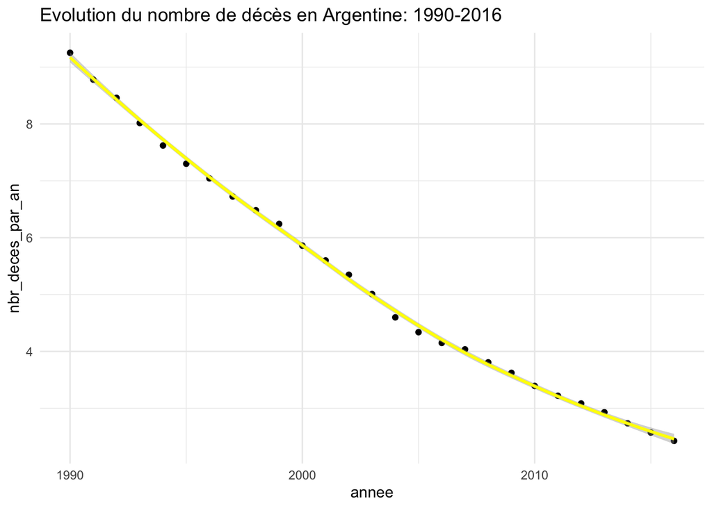

```r
data %>%
  filter(pays == "Argentina") %>%
  group_by(annee) %>%
  summarise(nbr_deces_par_an = sum(nbr.deces)) %>%
  ggplot(aes(x = annee, y = nbr_deces_par_an))+
  geom_point()+
  geom_smooth(color="yellow")+
  theme_minimal()+
  labs(title = "Evolution du nombre de décès en Argentine: 1990-2016")
```

*4.Quelle est l’evolution du nombre de décès dus au paludisme* *en France de 1990 à 2016?*

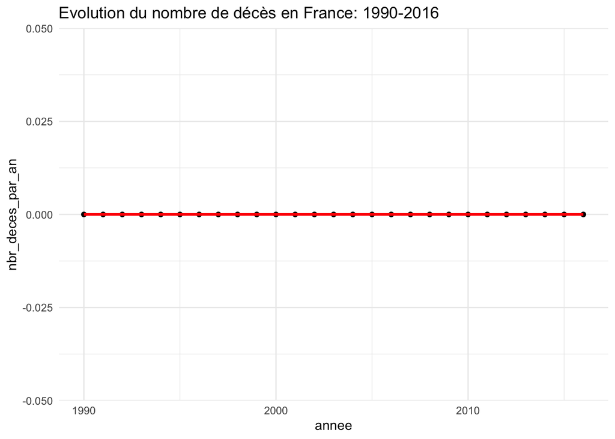

```r
data %>%
  filter(pays == "France") %>%
  group_by(annee) %>%
  summarise(nbr_deces_par_an = sum(nbr.deces)) %>%
  ggplot(aes(x = annee, y = nbr_deces_par_an))+
  geom_point()+
  geom_smooth(color="red")+
  theme_minimal()+
  labs(title = "Evolution du nombre de décès en France: 1990-2016")
```

La question 4 montre qu’il y’a des pays dont le nombre de décès dus au Paludisme au fil des années est égal à 0.

*5.Quels sont les pays dont la somme des nombres de décès dans le temps* *est egale à zero?*

```r
data %>%
   group_by(pays,annee) %>%
  summarise(nbr_deces_par_an = sum(nbr.deces)) %>%
   count(nbr_deces_par_an)%>%
  filter(nbr_deces_par_an == 0 & n==27) %>%
  select(pays)
```

```
## # A tibble: 91 x 1
## # Groups:   pays [91]
##    pays
##    <chr>
##  1 Albania
##  2 Andorra
##  3 Antigua and Barbuda
##  4 Australasia
##  5 Australia
##  6 Austria
##  7 Bahamas
##  8 Bahrain
##  9 Barbados
## 10 Belarus
## # … with 81 more rows
```

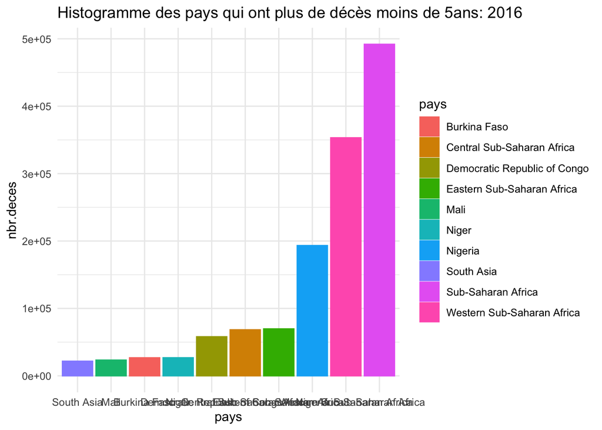

```r
data %>%
  filter(annee == 2016 &
           tranche_age == "Under 5" &
           nbr.deces != 0) %>%
  arrange(desc(nbr.deces))-> deces_moins_5_2016

deces_moins_5_2016 [1:13,]%>%
  filter(pays!= "Low SDI") %>%
  filter(pays!= "Low-middle SDI") %>%
  filter(pays != "World") %>%
  ggplot(aes(x= reorder(pays, nbr.deces), y = nbr.deces, color =pays, fill = pays))+
  geom_col()+
  xlab("pays")+
  theme_minimal()+
 labs(title = "Histogramme des pays qui ont plus de décès moins de 5ans: 2016")
```

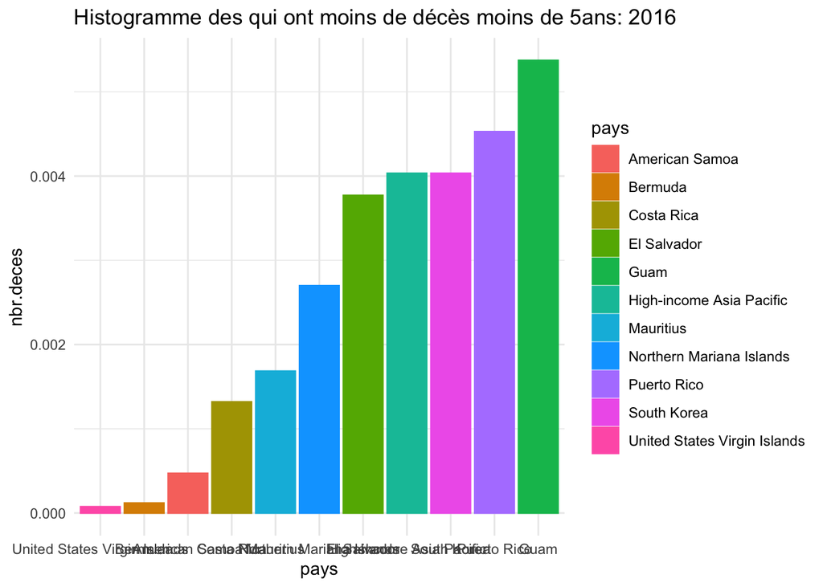

```r
data %>%
  filter(annee == 2016 &
           tranche_age == "Under 5" &
           nbr.deces != 0) %>%
  arrange(nbr.deces)-> deces_moins

deces_moins [1:11,]%>%
  filter(pays!= "High SDI") %>%
  ggplot(aes(x= reorder(pays, nbr.deces), y = nbr.deces, color =pays, fill = pays))+
  geom_col()+
  xlab("pays")+
  theme_minimal()+
  labs(title = "Histogramme des qui ont moins de décès moins de 5ans: 2016")
```

*8.Sur combien de pays porte notre étude?*

```r
data %>%
  distinct(pays) %>%
  filter(pays !="Low SDI") %>%
  filter(pays !="Low-middle SDI") %>%
  filter(pays !="World") %>%
  filter(pays !="High SDI") %>%
  filter(pays !="High-middle SDI" ) %>%
  count() %>%
  rename("Nombre de pays dans la base de données" = n)
```

```
## # A tibble: 1 x 1
##   `Nombre de pays dans la base de données`
##                                      <int>
## 1                                      223
```

*9.Nombre de décès par pays dus au paludisme en 2008?*

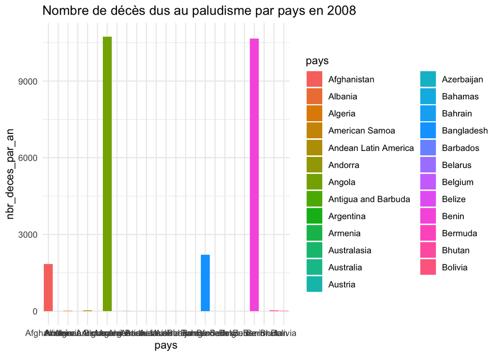

```r
data %>%
  filter(pays !="Low SDI") %>%
  filter(pays !="Low-middle SDI") %>%
  filter(pays !="World") %>%
  filter(pays !="High SDI") %>%
  filter(pays !="High-middle SDI" ) -> country


country %>%
  filter(annee == 2008) %>%
  group_by(pays,annee) %>%
  summarise(nbr_deces_par_an = sum(nbr.deces)) ->country_1

country_1 [1:25,] %>%
  ggplot(aes(x = pays, y = nbr_deces_par_an))+
  geom_col(aes(fill = pays))+
  theme_minimal()+
  labs(title = "Nombre de décès dus au paludisme par pays en 2008")
```

*10.50 pays qui ont le plus grand pourcentage de décés en 1998?*

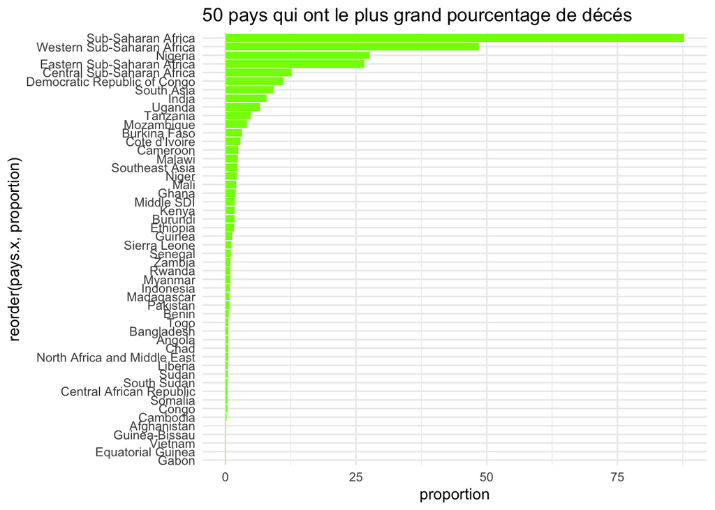

```r
#---nombre de décés par an et par pays
country %>%
  group_by(pays,annee) %>%
  summarise(nbr_deces_an = sum(nbr.deces)) ->country_2

#---nombre de décés par an dans le monde
data %>%
  filter(pays == "World") %>%
  group_by(pays,annee) %>%
  summarise(nbr_deces_World = sum(nbr.deces)) -> deces_world

#--- fusion des des tableau par pays
merge(country_2, deces_world, by ="annee")-> deces_per_pays_monde

#------pourcentage de décés par pays
#------ représentation 50 pays avec la plus grande proportion
deces_per_pays_monde %>%
  select(-pays.y) %>%
  mutate(proportion = (nbr_deces_an/nbr_deces_World)*100) %>%
  filter(annee == 1998 & proportion != 0.0) %>%
  arrange(desc(proportion))-> proportion_50

proportion_50[1:50,] %>%
  ggplot(aes(x = reorder(pays.x,proportion), y = proportion)) +
  geom_col(fill = "chartreuse")+
  coord_flip()+
  theme_minimal()+
  labs(title= "50 pays qui ont le plus grand pourcentage de décés")
```

*11.nombre total de décés dus au paludisme de chaque pays de 1990 à 2016* *par tranche d’age?*

```r
country %>%
  group_by(pays,tranche_age) %>%
  summarise(nbr_total= sum(nbr.deces)) %>%
 filter(nbr_total != 0) %>%
  arrange(desc(pays,nbr_total))->country_10

country_10[1:15,]
```

```
## # A tibble: 15 x 3
## # Groups:   pays [3]
##    pays     tranche_age nbr_total
##    <chr>    <chr>           <dbl>
##  1 Zimbabwe 15-49         8716.
##  2 Zimbabwe 5-14          3609.
##  3 Zimbabwe 50-69         2308.
##  4 Zimbabwe 70 or older   1545.
##  5 Zimbabwe Under 5       9441.
##  6 Zambia   15-49        16183.
##  7 Zambia   5-14         16696.
##  8 Zambia   50-69         8835.
##  9 Zambia   70 or older   5711.
## 10 Zambia   Under 5     142681.
## 11 Yemen    15-49          102.
## 12 Yemen    5-14             4.25
## 13 Yemen    50-69           21.2
## 14 Yemen    70 or older      7.00
## 15 Yemen    Under 5         23.7
```

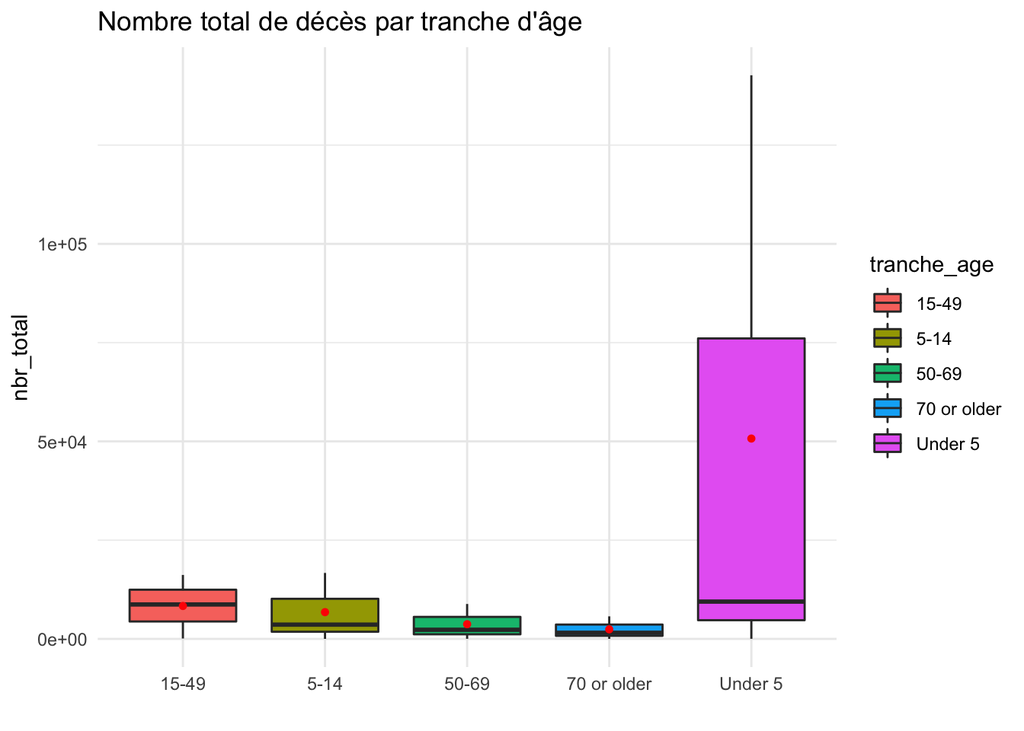

```r
 country_10[1:15,] %>%
   ggplot( aes(x=tranche_age, y=nbr_total, fill=tranche_age)) +
    geom_boxplot() +
   stat_summary(fun.y=mean, geom="point", shape=20, size=2, color="red", fill="red")+
    xlab("tranche_age") +
    theme(legend.position="none") +
    xlab("") +
    xlab("")+
    labs(title= "Nombre total de décès par tranche d'âge")+
      theme_minimal()
```